# Practical-Machine-Learning-Assignment

## Feature Selection

In order to select the relevant features, the various variables were plotted graphically. To begin, the variables were plotted a few at a time using boxplots in R’s `featurePlot()` function, like so:

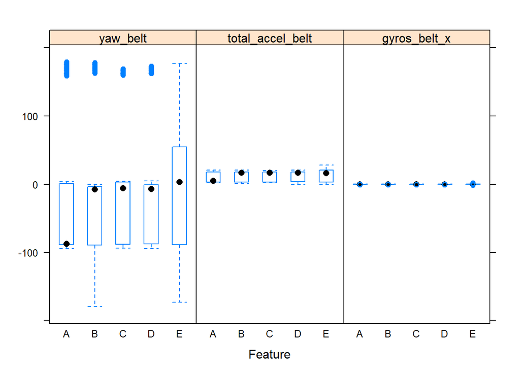

```r
featurePlot(x = myTraining[,8:10], y = myTraining$classe, plot = "box")
```

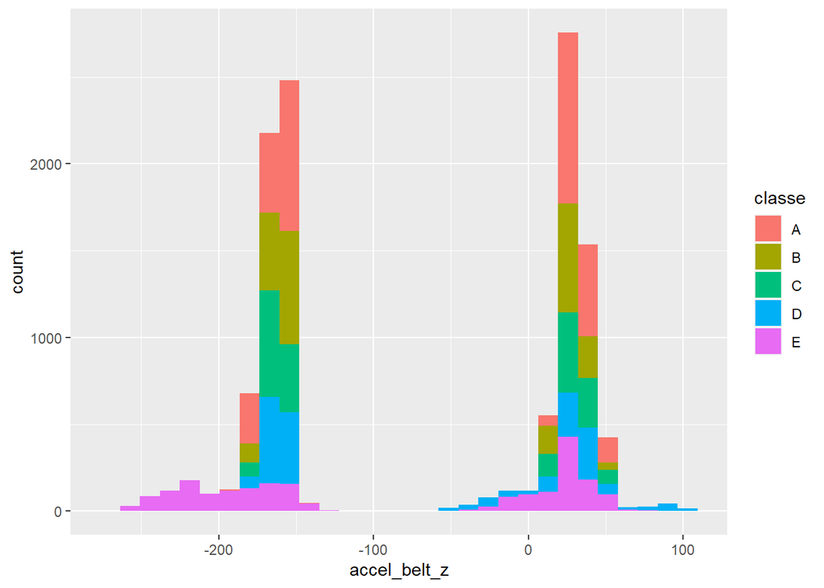

```r
ggplot(data = myTraining, aes(x = accel_belt_z, fill = classe)) + geom_histogram()
```

### Transform the Test and Testing data sets

Here is one of the golden rules of machine learning and modeling in general: models are built using training data, and evaluated on testing data. The reason is over-fitting: most models’ accuracy can be artificially increased to a point where they “learn” every single detail of the data used to build them; unfortunately, it usually means they lose the capability to generalize. That’s why we need unseen data (i.e., the testing set): if we over-fit the training data, the performance on the testing data will be poor.

```r
clean1 <- colnames(myTraining)
clean2 <- colnames(myTraining[, -58])  # remove the classe column
myTesting <- myTesting[clean1]         # allow only variables in myTesting that are also in myTraining
testing <- testing[clean2]             # allow only variables in testing that are also in myTraining

dim(myTesting)
```

[1] 7846 58

```r
#Coerce the data into the same type
for (i in 1:length(testing) ) {
    for(j in 1:length(myTraining)) {
        if( length( grep(names(myTraining[i]), names(testing)[j]) ) == 1)  {
            class(testing[j]) <- class(myTraining[i])
        }
    }
}

# To get the same class between testing and myTraining
testing <- rbind(myTraining[2, -58] , testing)
testing <- testing[-1,]
```

## Prediction with Decision Trees

A decision tree (also known as regression tree for continuous outcome variables) is a simple and popular machine learning algorithm, with a few interesting advantages over linear models: they make no assumptions about the relation between the outcome and predictors (i.e., they allow for linear and non-linear relations); the interpretability of a decision tree could not be higher - at the end of the process, a set of rules, in natural language, relating the outcome to the explanatory variables, can be easily derived from the tree.

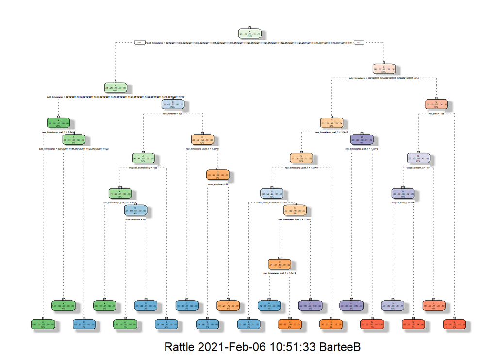

```r
set.seed(123) #For reproducibility; 123 has no particular meaning
modFitA1 <- rpart(classe ~ ., data=myTraining, method="class")

fancyRpartPlot(modFitA1)
```

### Confusion Matrix

```r
predictionsA1 <- predict(modFitA1, myTesting, type = "class")
cmtree <- confusionMatrix(predictionsA1, myTesting$classe)
cmtree
```

Confusion Matrix and Statistics

```
      Reference
```

Prediction A B C D E A 2107 74 12 0 0 B 119 1313 8 40 0 C 6 131 1231 78 0 D 0 0 56 962 82 E 0 0 61 206 1360

Overall Statistics

```
           Accuracy : 0.8887
             95% CI : (0.8816, 0.8956)
No Information Rate : 0.2845
P-Value [Acc > NIR] : < 2.2e-16

              Kappa : 0.8593
```

Mcnemar’s Test P-Value : NA

Statistics by Class:

```
                 Class: A Class: B Class: C Class: D Class: E
```

Sensitivity 0.9440 0.8650 0.8999 0.7481 0.9431 Specificity 0.9847 0.9736 0.9668 0.9790 0.9583 Pos Pred Value 0.9608 0.8872 0.8513 0.8745 0.8359 Neg Pred Value 0.9779 0.9678 0.9786 0.9520 0.9868 Prevalence 0.2845 0.1935 0.1744 0.1639 0.1838 Detection Rate 0.2685 0.1673 0.1569 0.1226 0.1733 Detection Prevalence 0.2795 0.1886 0.1843 0.1402 0.2074 Balanced Accuracy 0.9643 0.9193 0.9333 0.8635 0.9507

### Decision Tree Confusion Matrix

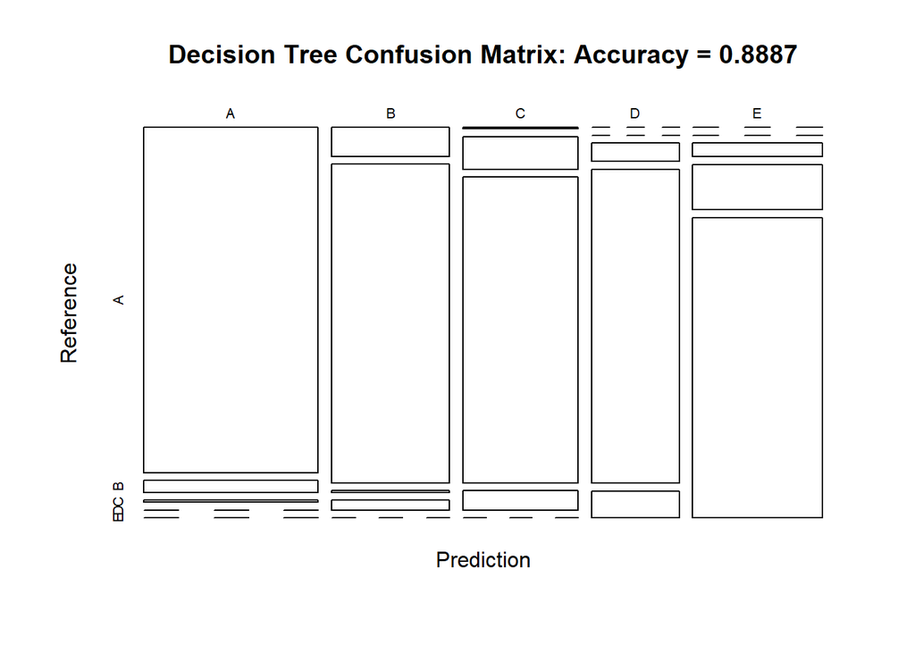

```r
plot(cmtree$table, col = cmtree$byClass, main = paste("Decision Tree Confusion Matrix: Accuracy =", round(cmtree$overall['Accuracy'], 4)))
```

## Prediction with Random Forests

What if, instead of growing a single tree, we grow many (ranging from a few hundred to a few thousand), and introduce some sources of randomness, so that each tree is most likely different from the others? What we get is a random forest

- How many trees are needed to reach the minimum error estimate?
- This is a simple problem; it appears that about 100 trees would be enough.

Some of most interesting characteristics of random forests are:

- They do not over-fit.
- There is no need for cross-validation.
- We can grow as many tree as we want (the limit is the computational power).
- Although we usually improve accuracy, it comes at a cost: interpretability.

```r
set.seed(123)  #For reproducibility; 123 has no particular meaning
modFitB1 <- randomForest(classe ~ ., data=myTraining, importance = TRUE, ntree=100)
predictionB1 <- predict(modFitB1, myTesting, type = "class")
cmrf <- confusionMatrix(predictionB1, myTesting$classe)
cmrf
```

Confusion Matrix and Statistics

```
      Reference
```

Prediction A B C D E A 2231 1 0 0 0 B 1 1517 7 0 0 C 0 0 1359 3 0 D 0 0 2 1282 0 E 0 0 0 1 1442

Overall Statistics

```
           Accuracy : 0.9981
             95% CI : (0.9968, 0.9989)
No Information Rate : 0.2845
P-Value [Acc > NIR] : < 2.2e-16

              Kappa : 0.9976
```

Mcnemar’s Test P-Value : NA

Statistics by Class:

```
                 Class: A Class: B Class: C Class: D Class: E
```

Sensitivity 0.9996 0.9993 0.9934 0.9969 1.0000 Specificity 0.9998 0.9987 0.9995 0.9997 0.9998 Pos Pred Value 0.9996 0.9948 0.9978 0.9984 0.9993 Neg Pred Value 0.9998 0.9998 0.9986 0.9994 1.0000 Prevalence 0.2845 0.1935 0.1744 0.1639 0.1838 Detection Rate 0.2843 0.1933 0.1732 0.1634 0.1838 Detection Prevalence 0.2845 0.1944 0.1736 0.1637 0.1839 Balanced Accuracy 0.9997 0.9990 0.9965 0.9983 0.9999

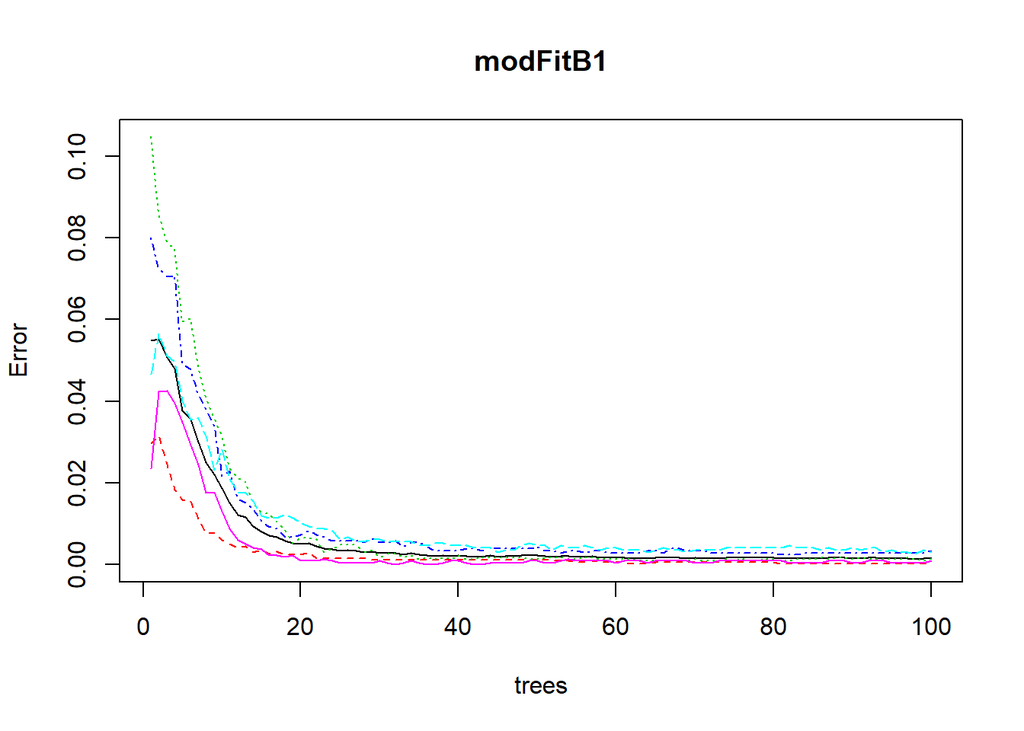

```r
plot(modFitB1)
```

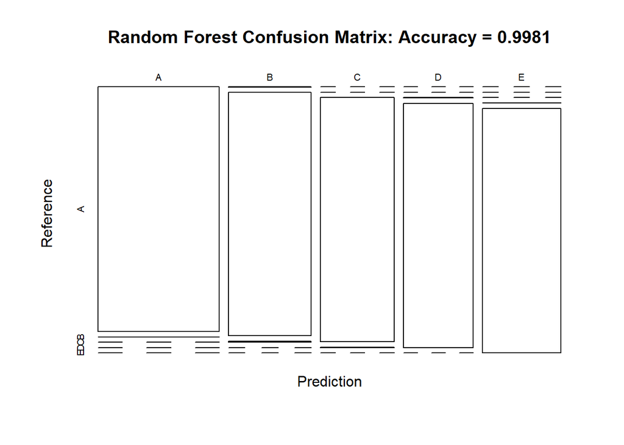

```r
plot(cmrf$table, col = cmtree$byClass, main = paste("Random Forest Confusion Matrix: Accuracy =", round(cmrf$overall['Accuracy'], 4)))
```

## Prediction with Generalized Boosted Regression

Gradient boosted machines (GBMs) are an extremely popular machine learning algorithm that have proven successful across many domains. Whereas random forests build an ensemble of deep independent trees, GBMs build an ensemble of shallow and weak successive trees with each tree learning and improving on the previous. When combined, these many weak successive trees produce a powerful “committee” that are often hard to beat with other algorithms

We will use 5-fold cross validation to estimate accuracy.

```r
set.seed(123)  #For reproducibility; 123 has no particular meaning

# Run algorithms using 5-fold cross validation repeated 1 times
fitControl <- trainControl(method = "repeatedcv",
                           number = 5,
                           repeats = 1)

# Using caret with the default grid to optimize tune parameters automatically
# GBM Tuning parameters:
# n.trees (# Boosting Iterations)
# interaction.depth (Max Tree Depth)
# shrinkage (Shrinkage)
# n.minobsinnode (Min. Terminal Node Size)

gbmFit1 <- train(classe ~ .
                 , data = myTraining
                 , method = "gbm"
                 , trControl = fitControl
                 , verbose = FALSE
                )




gbmFinMod1 <- gbmFit1$finalModel

gbmPredTest <- predict(gbmFit1, newdata=myTesting)
gbmAccuracyTest <- confusionMatrix(gbmPredTest, myTesting$classe)
gbmAccuracyTest
```

Confusion Matrix and Statistics

```
      Reference
```

Prediction A B C D E A 2232 0 0 0 0 B 0 1514 2 0 0 C 0 2 1360 3 0 D 0 2 6 1282 3 E 0 0 0 1 1439

Overall Statistics

```
           Accuracy : 0.9976
             95% CI : (0.9962, 0.9985)
No Information Rate : 0.2845
P-Value [Acc > NIR] : < 2.2e-16

              Kappa : 0.9969
```

Mcnemar’s Test P-Value : NA

Statistics by Class:

```
                 Class: A Class: B Class: C Class: D Class: E
```

Sensitivity 1.0000 0.9974 0.9942 0.9969 0.9979 Specificity 1.0000 0.9997 0.9992 0.9983 0.9998 Pos Pred Value 1.0000 0.9987 0.9963 0.9915 0.9993 Neg Pred Value 1.0000 0.9994 0.9988 0.9994 0.9995 Prevalence 0.2845 0.1935 0.1744 0.1639 0.1838 Detection Rate 0.2845 0.1930 0.1733 0.1634 0.1834 Detection Prevalence 0.2845 0.1932 0.1740 0.1648 0.1835 Balanced Accuracy 1.0000 0.9985 0.9967 0.9976 0.9989

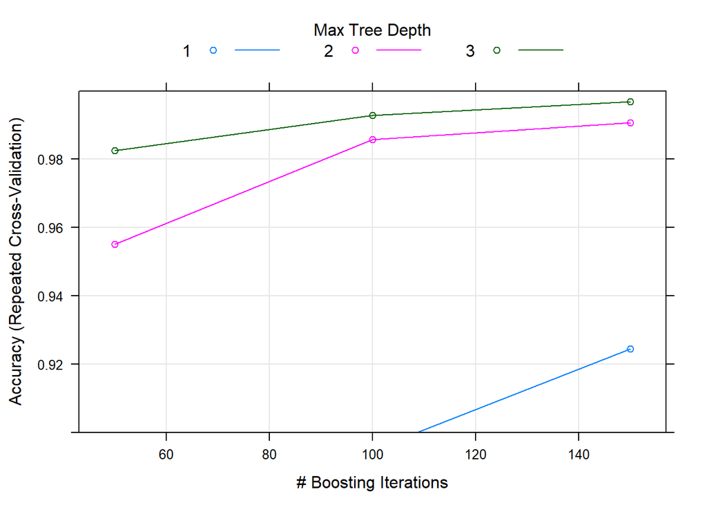

```r
plot(gbmFit1, ylim=c(0.9, 1))
```

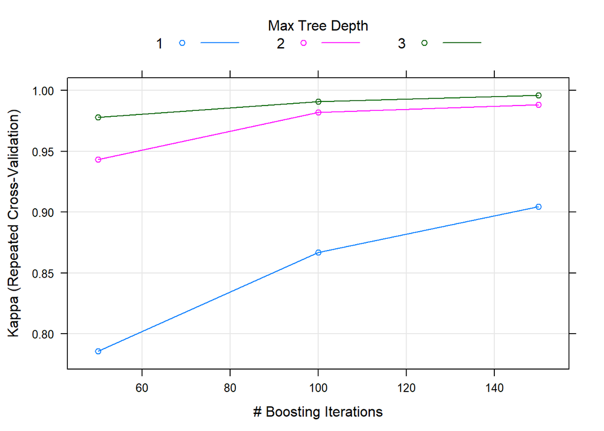

```r
plot(gbmFit1, metric = "Kappa")
```

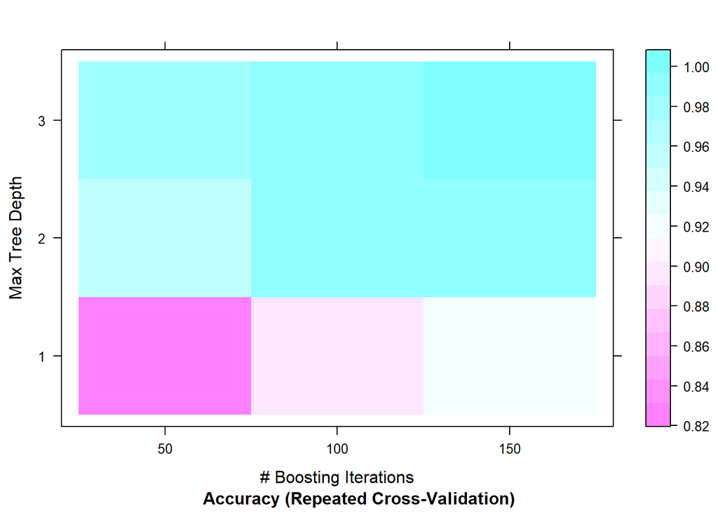

```r
plot(gbmFit1, plotType = "level")
```

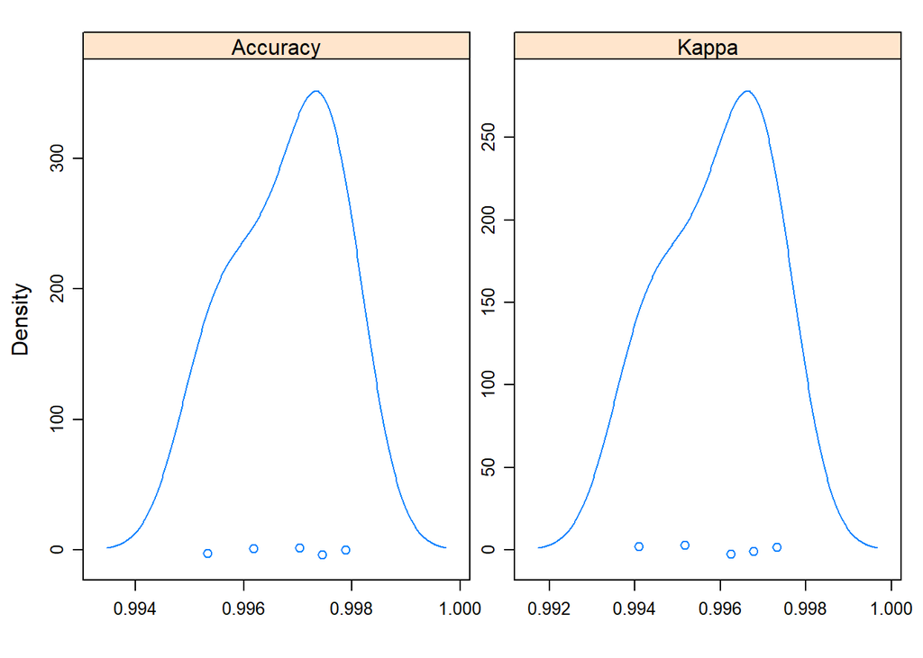

```r
resampleHist(gbmFit1)
```

## Predicting Results on the Test Data

Random Forests gave an Accuracy in the Testing data set of 99.81%, which was more accurate that what I got from the Decision Trees or GBM.

- The expected out-of-sample error is 100% -99.81% = 0.19%.

```r
predictionB2 <- predict(modFitB1, testing, type = "class")
predictionB2
```

1 21 3 4 5 6 7 8 9 10 11 12 13 14 15 16 17 18 19 20 B A B A A E D B A A B C B A E E A B B B Levels: A B C D E

```r
# Write the results to a text file for submission
pml_write_files = function(x){
    n = length(x)
    for(i in 1:n){
        filename = paste0("problem_id_",i,".txt")
        write.table(x[i],file=filename,quote=FALSE,row.names=FALSE,col.names=FALSE)
    }
}
```